# Practical Machine Learning Assignment

Derek Geng

5 augustus 2017

## Background

Using devices such as Jawbone Up, Nike FuelBand, and Fitbit it is now possible to collect a large amount of data about personal activity relatively inexpensively. These type of devices are part of the quantified self movement - a group of enthusiasts who take measurements about themselves regularly to improve their health, to find patterns in their behavior, or because they are tech geeks. One thing that people regularly do is quantify how much of a particular activity they do, but they rarely quantify how well they do it. In this project, your goal will be to use data from accelerometers on the belt, forearm, arm, and dumbell of 6 participants. They were asked to perform barbell lifts correctly and incorrectly in 5 different ways. More information is available from the website here: http://web.archive.org/web/20161224072740/http:/groupware.les.inf.puc-rio.br/har (see the section on the Weight Lifting Exercise Dataset).

## Data

The training data for this project are available here:

https://d396qusza40orc.cloudfront.net/predmachlearn/pml-training.csv

The test data are available here:

https://d396qusza40orc.cloudfront.net/predmachlearn/pml-testing.csv

## goal

The goal of your project is to predict the manner in which they did the exercise. This is the “classe” variable in the training set. You may use any of the other variables to predict with. You should create a report describing how you built your model, how you used cross validation, what you think the expected out of sample error is, and why you made the choices you did. You will also use your prediction model to predict 20 different test cases.

# Prepare the data

in case you do not have some of the packages. Helpful codes: setwd(), .libPaths(), install.packages()

```r
library(caret)
```

```r
library(rpart)
library(rpart.plot)
library(RColorBrewer)
library(rattle)
library(randomForest)
library(knitr)

library(corrplot)
library(ggthemes)
library(gridExtra)
library(ggplot2)
library(grid)


set.seed(10000)

trainDataURL <- "http://d396qusza40orc.cloudfront.net/predmachlearn/pml-training.csv"
testDataURL <- "http://d396qusza40orc.cloudfront.net/predmachlearn/pml-testing.csv"

trainingData <- read.csv(url(trainDataURL),na.strings=c("NA","#DIV/0!",""))

testingData <- read.csv(url(testDataURL), na.strings=c("NA","#DIV/0!",""))
```

# Data cleaning

firsr remove all the NA, second remove the nealy zero variance (NZV) variables.

```r
trainingData <- trainingData[, colSums(is.na(trainingData)) == 0]

testingData <- testingData[, colSums(is.na(testingData)) == 0]

dim(trainingData)
```

```
## [1] 19622    60
```

```r
dim(testingData)
```

```
## [1] 20 60
```

```r
nzv <- nearZeroVar(trainingData)
trainingData <- trainingData[,-nzv]

nzv<- nearZeroVar(testingData)
testingData <- testingData[,-nzv]

dim(trainingData)
```

```
## [1] 19622    59
```

```r
dim(testingData)
```

```
## [1] 20 59
```

# Data splitting

split the training data with 60 percent training set and 40 percent validation set.

```r
inTrain <- createDataPartition(trainingData$classe, p=0.6, list=FALSE)

TrainSet <- trainingData[inTrain, ]
ValidSet <- trainingData[-inTrain, ]

dim(TrainSet)
```

```
## [1] 11776    59
```

```r
dim(ValidSet)
```

```
## [1] 7846   59
```

remove the first five columns which only contain indentification variables

```r
TrainSet <- TrainSet[, -(1:5)]
ValidSet  <- ValidSet[, -(1:5)]

dim(TrainSet)
```

```
## [1] 11776    54
```

```r
dim(ValidSet)
```

```
## [1] 7846   54
```

# correlation analysis

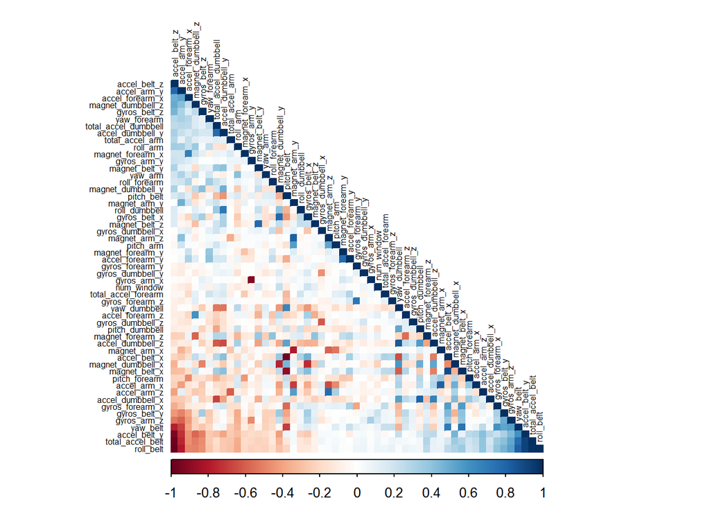

```r
corMatrix <- cor(TrainSet[, -54])

corrplot(corMatrix, order = "FPC", method = "color", type = "lower",
         tl.cex = 0.5, tl.col = rgb(0, 0, 0))
```